# SARFRAZ_HW4

# Question 4 (scatter plot with regression line)

Is there a relationship between the age of a plane and its delays?

Answer

Now I am going to find out if there is a relationship between a planes age and its delays. To start I have to join the flights dataset with the planes dataset.

Here is my scatter plot graph of a planes age and the average departure delay as the plane age increases.

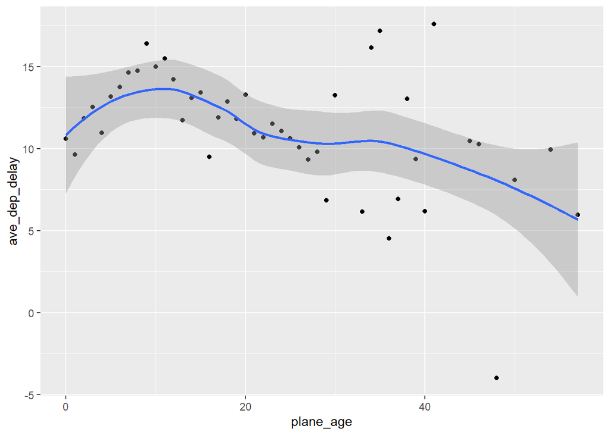

```r
flights %>%
  left_join(planes, by= "tailnum") %>%
  mutate(plane_age = year.x - year.y) %>%
  group_by(plane_age) %>%
  summarize(ave_dep_delay = mean(dep_delay, na.rm=T),
            ave_arr_delay = mean(arr_delay, na.rm=T)) %>%
   ggplot(mapping = aes(x=plane_age, y=ave_dep_delay)) +
   geom_point() + geom_smooth()
```

The scatterplot shows that there is not a relationship between `plane age` and `departure delays` because throughout the planes lifecycle most of the points with a plane age of 0-30 is in the 10-20 range and it does not decrease. There are a few points after the plane age of 30 that have a departure delay below 10.

This graph could possibly suggest that as a plane gets older it experiences less departure delays. But ultimately, no matter what the planes age it would most likely experience a departure delay. There is one outlier point that does have a negative departure delay (this outlier point has a plane age close to 50). But this outlier is only one point and it does not acculturatly represent the data.

Here is my scatter plot graph of a planes age and the average arrival delay as the plane ages.

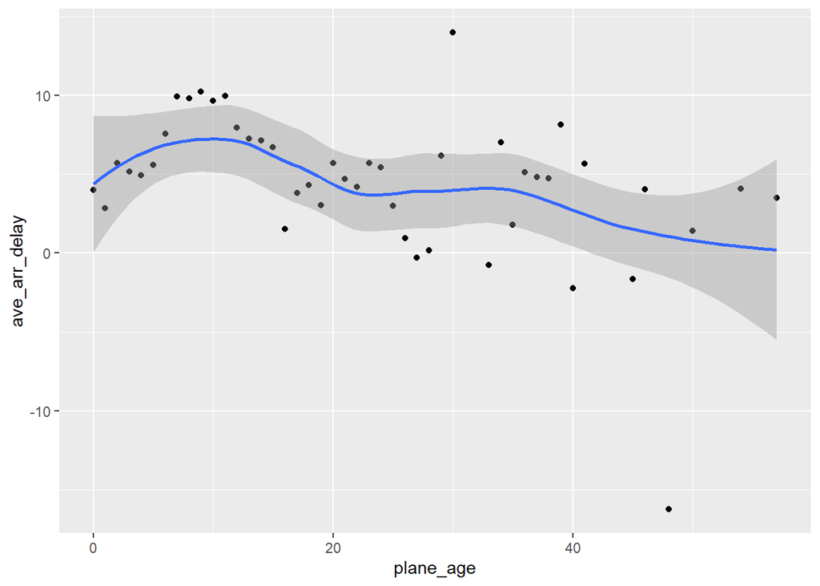

```r
flights %>%
   left_join(planes, by= "tailnum") %>%
   mutate(plane_age = year.x - year.y) %>%
   group_by(plane_age) %>%
   summarize(ave_dep_delay = mean(dep_delay, na.rm=T),
             ave_arr_delay = mean(arr_delay, na.rm=T)) %>%
   ggplot(mapping = aes(x=plane_age, y=ave_arr_delay)) +
   geom_point() +
  geom_smooth()
```

As shown in the scatterplot the relationship between “plane age” and “arrival delays” does not exist, but it is stronger than the relationship between “plane age” and “departure delays”.

This is because most of the points in the scattersplot have a delay between 0-10. Majority of the points in the “plane age** and”departure delays” scatterplot had a delay which was greater than 10 which suggests that the average arrival delay time would most likely be lower (by a few minutes) than the average departure delay time.

A possible explanation for this difference between departure and arrival delays could be that before a plane departures it needs to go through aircraft cleaning and loading the luggage off the plane. When a plane arrives the moment the plane lands on a airport is counted as arriving and the other factors are not taken into consideration (such as aircraft cleaning and loading the luggage off the plane).